# Risk Factor Analysis

## Outcome Variable

**Outcome Variable:** sstunted

## Predictor Variables

**Intervention Variable:** enstunt

**Adjustment Set:**

unadjusted

## Stratifying Variables

The analysis was stratified on these variable(s):

- agecat
- studyid

The following strata were considered:

- agecat: 12 months, studyid: ki0047075b-MAL-ED
- agecat: 12 months, studyid: ki1000108-CMC-V-BCS-2002
- agecat: 12 months, studyid: ki1000108-IRC
- agecat: 12 months, studyid: ki1000109-EE
- agecat: 12 months, studyid: ki1000109-ResPak
- agecat: 12 months, studyid: ki1000304b-SAS-FoodSuppl
- agecat: 12 months, studyid: ki1017093-NIH-Birth
- agecat: 12 months, studyid: ki1017093c-NIH-Crypto
- agecat: 12 months, studyid: ki1066203-TanzaniaChild2
- agecat: 12 months, studyid: ki1101329-Keneba
- agecat: 12 months, studyid: ki1112895-Guatemala BSC
- agecat: 12 months, studyid: ki1113344-GMS-Nepal
- agecat: 12 months, studyid: ki1114097-CMIN
- agecat: 12 months, studyid: ki1114097-CONTENT
- agecat: 12 months, studyid: ki1126311-ZVITAMBO
- agecat: 12 months, studyid: ki1135781-COHORTS
- agecat: 12 months, studyid: ki1148112-LCNI-5
- agecat: 18 months, studyid: ki0047075b-MAL-ED
- agecat: 18 months, studyid: ki1000108-CMC-V-BCS-2002
- agecat: 18 months, studyid: ki1000108-IRC
- agecat: 18 months, studyid: ki1000109-EE
- agecat: 18 months, studyid: ki1000109-ResPak
- agecat: 18 months, studyid: ki1000304b-SAS-FoodSuppl
- agecat: 18 months, studyid: ki1017093-NIH-Birth
- agecat: 18 months, studyid: ki1017093c-NIH-Crypto
- agecat: 18 months, studyid: ki1066203-TanzaniaChild2
- agecat: 18 months, studyid: ki1101329-Keneba
- agecat: 18 months, studyid: ki1113344-GMS-Nepal
- agecat: 18 months, studyid: ki1114097-CMIN
- agecat: 18 months, studyid: ki1114097-CONTENT
- agecat: 18 months, studyid: ki1126311-ZVITAMBO
- agecat: 18 months, studyid: ki1135781-COHORTS
- agecat: 18 months, studyid: ki1148112-LCNI-5
- agecat: 24 months, studyid: ki0047075b-MAL-ED
- agecat: 24 months, studyid: ki1000108-CMC-V-BCS-2002
- agecat: 24 months, studyid: ki1000108-IRC
- agecat: 24 months, studyid: ki1017093-NIH-Birth
- agecat: 24 months, studyid: ki1017093c-NIH-Crypto
- agecat: 24 months, studyid: ki1101329-Keneba
- agecat: 24 months, studyid: ki1113344-GMS-Nepal
- agecat: 24 months, studyid: ki1114097-CMIN
- agecat: 24 months, studyid: ki1114097-CONTENT
- agecat: 24 months, studyid: ki1126311-ZVITAMBO
- agecat: 24 months, studyid: ki1135781-COHORTS
- agecat: 24 months, studyid: ki1148112-LCNI-5
- agecat: 3 months, studyid: ki0047075b-MAL-ED
- agecat: 3 months, studyid: ki1000108-CMC-V-BCS-2002
- agecat: 3 months, studyid: ki1000108-IRC
- agecat: 3 months, studyid: ki1000109-EE
- agecat: 3 months, studyid: ki1000109-ResPak
- agecat: 3 months, studyid: ki1000304b-SAS-FoodSuppl
- agecat: 3 months, studyid: ki1017093-NIH-Birth
- agecat: 3 months, studyid: ki1017093c-NIH-Crypto
- agecat: 3 months, studyid: ki1066203-TanzaniaChild2
- agecat: 3 months, studyid: ki1101329-Keneba
- agecat: 3 months, studyid: ki1112895-Guatemala BSC
- agecat: 3 months, studyid: ki1113344-GMS-Nepal
- agecat: 3 months, studyid: ki1114097-CMIN
- agecat: 3 months, studyid: ki1114097-CONTENT
- agecat: 3 months, studyid: ki1126311-ZVITAMBO
- agecat: 3 months, studyid: ki1135781-COHORTS
- agecat: 6 months, studyid: ki0047075b-MAL-ED
- agecat: 6 months, studyid: ki1000108-CMC-V-BCS-2002
- agecat: 6 months, studyid: ki1000108-IRC
- agecat: 6 months, studyid: ki1000109-EE
- agecat: 6 months, studyid: ki1000109-ResPak
- agecat: 6 months, studyid: ki1000304b-SAS-FoodSuppl
- agecat: 6 months, studyid: ki1017093-NIH-Birth
- agecat: 6 months, studyid: ki1017093c-NIH-Crypto
- agecat: 6 months, studyid: ki1066203-TanzaniaChild2
- agecat: 6 months, studyid: ki1101329-Keneba
- agecat: 6 months, studyid: ki1112895-Guatemala BSC
- agecat: 6 months, studyid: ki1113344-GMS-Nepal
- agecat: 6 months, studyid: ki1114097-CMIN
- agecat: 6 months, studyid: ki1114097-CONTENT
- agecat: 6 months, studyid: ki1126311-ZVITAMBO
- agecat: 6 months, studyid: ki1135781-COHORTS
- agecat: 6 months, studyid: ki1148112-LCNI-5
- agecat: 9 months, studyid: ki0047075b-MAL-ED
- agecat: 9 months, studyid: ki1000108-CMC-V-BCS-2002
- agecat: 9 months, studyid: ki1000108-IRC
- agecat: 9 months, studyid: ki1000109-EE
- agecat: 9 months, studyid: ki1000109-ResPak
- agecat: 9 months, studyid: ki1000304b-SAS-FoodSuppl
- agecat: 9 months, studyid: ki1017093-NIH-Birth
- agecat: 9 months, studyid: ki1017093c-NIH-Crypto
- agecat: 9 months, studyid: ki1066203-TanzaniaChild2
- agecat: 9 months, studyid: ki1101329-Keneba
- agecat: 9 months, studyid: ki1112895-Guatemala BSC
- agecat: 9 months, studyid: ki1113344-GMS-Nepal
- agecat: 9 months, studyid: ki1114097-CMIN
- agecat: 9 months, studyid: ki1114097-CONTENT
- agecat: 9 months, studyid: ki1126311-ZVITAMBO
- agecat: 9 months, studyid: ki1135781-COHORTS
- agecat: 9 months, studyid: ki1148112-LCNI-5
- agecat: Birth, studyid: ki0047075b-MAL-ED
- agecat: Birth, studyid: ki1000108-CMC-V-BCS-2002
- agecat: Birth, studyid: ki1000108-IRC
- agecat: Birth, studyid: ki1000109-EE
- agecat: Birth, studyid: ki1000109-ResPak
- agecat: Birth, studyid: ki1017093-NIH-Birth
- agecat: Birth, studyid: ki1017093c-NIH-Crypto
- agecat: Birth, studyid: ki1101329-Keneba
- agecat: Birth, studyid: ki1114097-CMIN
- agecat: Birth, studyid: ki1114097-CONTENT
- agecat: Birth, studyid: ki1126311-ZVITAMBO
- agecat: Birth, studyid: ki1135781-COHORTS

### Dropped Strata

Some strata were dropped due to rare outcomes:

- agecat: Birth, studyid: ki0047075b-MAL-ED
- agecat: Birth, studyid: ki1000108-CMC-V-BCS-2002
- agecat: Birth, studyid: ki1000108-IRC
- agecat: Birth, studyid: ki1000109-EE
- agecat: Birth, studyid: ki1000109-ResPak
- agecat: Birth, studyid: ki1017093-NIH-Birth
- agecat: Birth, studyid: ki1017093c-NIH-Crypto
- agecat: Birth, studyid: ki1101329-Keneba
- agecat: Birth, studyid: ki1114097-CMIN
- agecat: Birth, studyid: ki1114097-CONTENT
- agecat: Birth, studyid: ki1126311-ZVITAMBO
- agecat: Birth, studyid: ki1135781-COHORTS
- agecat: 3 months, studyid: ki1000108-CMC-V-BCS-2002
- agecat: 3 months, studyid: ki1000109-EE
- agecat: 3 months, studyid: ki1000304b-SAS-FoodSuppl
- agecat: 3 months, studyid: ki1017093c-NIH-Crypto
- agecat: 3 months, studyid: ki1066203-TanzaniaChild2
- agecat: 3 months, studyid: ki1112895-Guatemala BSC
- agecat: 3 months, studyid: ki1113344-GMS-Nepal
- agecat: 3 months, studyid: ki1114097-CMIN
- agecat: 3 months, studyid: ki1114097-CONTENT
- agecat: 6 months, studyid: ki1000108-CMC-V-BCS-2002
- agecat: 6 months, studyid: ki1000109-EE
- agecat: 6 months, studyid: ki1000304b-SAS-FoodSuppl
- agecat: 6 months, studyid: ki1017093c-NIH-Crypto
- agecat: 6 months, studyid: ki1066203-TanzaniaChild2
- agecat: 6 months, studyid: ki1112895-Guatemala BSC
- agecat: 6 months, studyid: ki1113344-GMS-Nepal
- agecat: 6 months, studyid: ki1114097-CMIN
- agecat: 6 months, studyid: ki1114097-CONTENT
- agecat: 6 months, studyid: ki1148112-LCNI-5
- agecat: 9 months, studyid: ki1000108-CMC-V-BCS-2002
- agecat: 9 months, studyid: ki1000109-EE
- agecat: 9 months, studyid: ki1000109-ResPak
- agecat: 9 months, studyid: ki1000304b-SAS-FoodSuppl
- agecat: 9 months, studyid: ki1017093c-NIH-Crypto
- agecat: 9 months, studyid: ki1066203-TanzaniaChild2
- agecat: 9 months, studyid: ki1112895-Guatemala BSC
- agecat: 9 months, studyid: ki1113344-GMS-Nepal
- agecat: 9 months, studyid: ki1114097-CONTENT
- agecat: 9 months, studyid: ki1148112-LCNI-5
- agecat: 12 months, studyid: ki1000108-CMC-V-BCS-2002
- agecat: 12 months, studyid: ki1000109-EE
- agecat: 12 months, studyid: ki1000109-ResPak
- agecat: 12 months, studyid: ki1017093c-NIH-Crypto
- agecat: 12 months, studyid: ki1066203-TanzaniaChild2
- agecat: 12 months, studyid: ki1112895-Guatemala BSC
- agecat: 12 months, studyid: ki1113344-GMS-Nepal
- agecat: 12 months, studyid: ki1114097-CONTENT
- agecat: 12 months, studyid: ki1148112-LCNI-5
- agecat: 18 months, studyid: ki1000108-CMC-V-BCS-2002
- agecat: 18 months, studyid: ki1000109-EE
- agecat: 18 months, studyid: ki1000109-ResPak
- agecat: 18 months, studyid: ki1017093c-NIH-Crypto
- agecat: 18 months, studyid: ki1066203-TanzaniaChild2
- agecat: 18 months, studyid: ki1113344-GMS-Nepal
- agecat: 18 months, studyid: ki1114097-CONTENT
- agecat: 24 months, studyid: ki1000108-CMC-V-BCS-2002
- agecat: 24 months, studyid: ki1017093c-NIH-Crypto
- agecat: 24 months, studyid: ki1113344-GMS-Nepal
- agecat: 24 months, studyid: ki1114097-CONTENT
- agecat: 24 months, studyid: ki1126311-ZVITAMBO

## Methods Detail

We’re interested in the causal parameters $E[Y_a]$ for all values of $a \in \mathcal{A}$. These parameters represent the mean outcome if, possibly contrary to fact, we intervened to set all units to have $A=a$. Under the randomization and positivity assumptions, these are identified by the statistical parameters $\psi_a=E_W[E_{Y|A,W}(Y|A=a,W)]$. In addition, we’re interested in the mean of $Y$, $E[Y]$ under no intervention (the observed mean). We will estimate these parameters by using SuperLearner to fit the relevant likelihood factors – $E_{Y|A,W}(Y|A=a,W)$ and $p(A=a|W)$, and then updating our likelihood fit using a joint TMLE.

For unadjusted analyses ($W=\{\}$), initial likelihoods were estimated using Lrnr_glm to estimate the simple $E(Y|A)$ and Lrnr_mean to estimate $p(A)$. For adjusted analyses, a small library containing Lrnr_glmnet, Lrnr_xgboost, and Lrnr_mean was used.

Having estimated these parameters, we will then use the delta method to estimate relative risks and attributable risks relative to a prespecified baseline level of $A$.

# Results Detail

## Results Plots

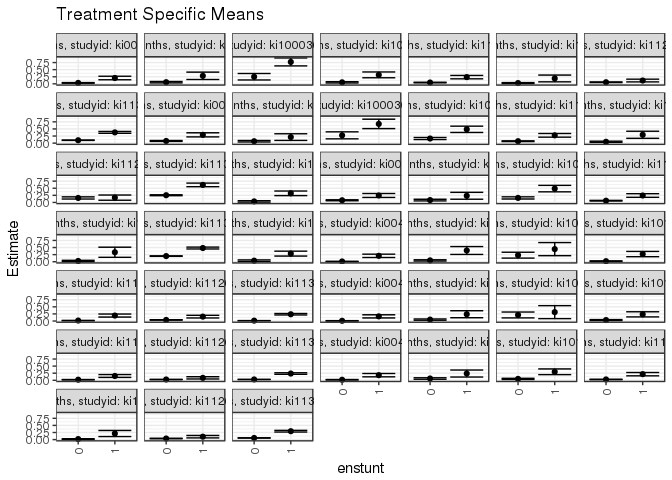

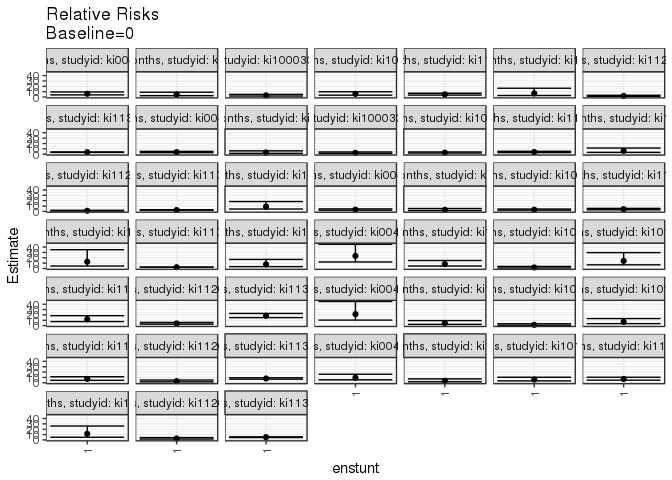

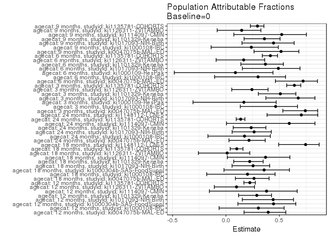

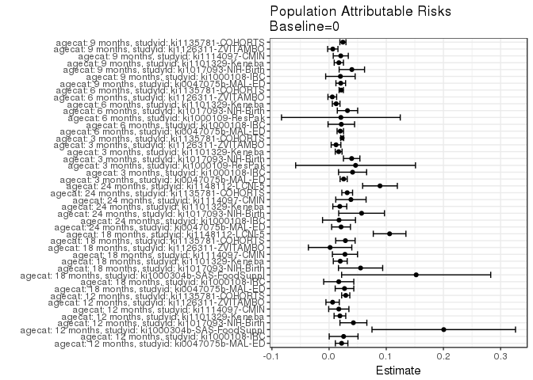

## Data Summary

| agecat | studyid | A | n | nA | nAY0 | nAY1 |
| --- | --- | --- | --- | --- | --- | --- |
| Birth | ki0047075b-MAL-ED | 0 | 1499 | 1300 | 1300 | 0 |
| Birth | ki0047075b-MAL-ED | 1 | 1499 | 199 | 153 | 46 |
| Birth | ki1000108-CMC-V-BCS-2002 | 0 | 90 | 74 | 74 | 0 |
| Birth | ki1000108-CMC-V-BCS-2002 | 1 | 90 | 16 | 13 | 3 |
| Birth | ki1000108-IRC | 0 | 388 | 343 | 343 | 0 |
| Birth | ki1000108-IRC | 1 | 388 | 45 | 29 | 16 |
| Birth | ki1000109-EE | 0 | 2 | 1 | 1 | 0 |
| Birth | ki1000109-EE | 1 | 2 | 1 | 1 | 0 |
| Birth | ki1000109-ResPak | 0 | 7 | 5 | 5 | 0 |
| Birth | ki1000109-ResPak | 1 | 7 | 2 | 2 | 0 |
| Birth | ki1000304b-SAS-FoodSuppl | 0 | 0 | 0 | 0 | 0 |
| Birth | ki1000304b-SAS-FoodSuppl | 1 | 0 | 0 | 0 | 0 |
| Birth | ki1017093-NIH-Birth | 0 | 28 | 27 | 27 | 0 |
| Birth | ki1017093-NIH-Birth | 1 | 28 | 1 | 1 | 0 |
| Birth | ki1017093c-NIH-Crypto | 0 | 27 | 22 | 22 | 0 |
| Birth | ki1017093c-NIH-Crypto | 1 | 27 | 5 | 4 | 1 |
| Birth | ki1066203-TanzaniaChild2 | 0 | 0 | 0 | 0 | 0 |
| Birth | ki1066203-TanzaniaChild2 | 1 | 0 | 0 | 0 | 0 |
| Birth | ki1101329-Keneba | 0 | 1541 | 1459 | 1459 | 0 |
| Birth | ki1101329-Keneba | 1 | 1541 | 82 | 53 | 29 |
| Birth | ki1112895-Guatemala BSC | 0 | 0 | 0 | 0 | 0 |
| Birth | ki1112895-Guatemala BSC | 1 | 0 | 0 | 0 | 0 |
| Birth | ki1113344-GMS-Nepal | 0 | 0 | 0 | 0 | 0 |
| Birth | ki1113344-GMS-Nepal | 1 | 0 | 0 | 0 | 0 |
| Birth | ki1114097-CMIN | 0 | 138 | 127 | 127 | 0 |
| Birth | ki1114097-CMIN | 1 | 138 | 11 | 3 | 8 |
| Birth | ki1114097-CONTENT | 0 | 2 | 2 | 2 | 0 |
| Birth | ki1114097-CONTENT | 1 | 2 | 0 | 0 | 0 |
| Birth | ki1126311-ZVITAMBO | 0 | 3449 | 3089 | 3089 | 0 |
| Birth | ki1126311-ZVITAMBO | 1 | 3449 | 360 | 248 | 112 |

[output cut: 208 more lines]

## Results Table

### Parameter: TSM

| agecat | studyid | intervention_level | baseline_level | estimate | ci_lower | ci_upper |
| --- | --- | --- | --- | --- | --- | --- |
| 3 months | ki0047075b-MAL-ED | 0 | NA | 0.0088424 | 0.0036383 | 0.0140466 |
| 3 months | ki0047075b-MAL-ED | 1 | NA | 0.2076503 | 0.1488608 | 0.2664397 |
| 3 months | ki1000108-IRC | 0 | NA | 0.0473538 | 0.0253560 | 0.0693515 |
| 3 months | ki1000108-IRC | 1 | NA | 0.3958333 | 0.2573185 | 0.5343481 |
| 3 months | ki1000109-ResPak | 0 | NA | 0.2307692 | 0.1277209 | 0.3338175 |
| 3 months | ki1000109-ResPak | 1 | NA | 0.4444444 | 0.2134953 | 0.6753936 |
| 3 months | ki1017093-NIH-Birth | 0 | NA | 0.0189076 | 0.0066613 | 0.0311538 |
| 3 months | ki1017093-NIH-Birth | 1 | NA | 0.2696629 | 0.1773824 | 0.3619434 |
| 3 months | ki1101329-Keneba | 0 | NA | 0.0161535 | 0.0106008 | 0.0217061 |
| 3 months | ki1101329-Keneba | 1 | NA | 0.1923077 | 0.1387358 | 0.2458796 |
| 3 months | ki1126311-ZVITAMBO | 0 | NA | 0.0378298 | 0.0294853 | 0.0461742 |
| 3 months | ki1126311-ZVITAMBO | 1 | NA | 0.1545064 | 0.1080875 | 0.2009254 |
| 3 months | ki1135781-COHORTS | 0 | NA | 0.0128788 | 0.0105797 | 0.0151779 |
| 3 months | ki1135781-COHORTS | 1 | NA | 0.2382775 | 0.2124459 | 0.2641091 |
| 6 months | ki0047075b-MAL-ED | 0 | NA | 0.0075694 | 0.0026411 | 0.0124977 |
| 6 months | ki0047075b-MAL-ED | 1 | NA | 0.1637427 | 0.1082596 | 0.2192258 |
| 6 months | ki1000108-IRC | 0 | NA | 0.0498615 | 0.0273811 | 0.0723419 |
| 6 months | ki1000108-IRC | 1 | NA | 0.2391304 | 0.1157132 | 0.3625477 |
| 6 months | ki1000109-ResPak | 0 | NA | 0.2131148 | 0.1096758 | 0.3165537 |
| 6 months | ki1000109-ResPak | 1 | NA | 0.3125000 | 0.0838938 | 0.5411062 |
| 6 months | ki1017093-NIH-Birth | 0 | NA | 0.0334821 | 0.0168086 | 0.0501557 |
| 6 months | ki1017093-NIH-Birth | 1 | NA | 0.2352941 | 0.1450333 | 0.3255549 |
| 6 months | ki1101329-Keneba | 0 | NA | 0.0211528 | 0.0146658 | 0.0276399 |
| 6 months | ki1101329-Keneba | 1 | NA | 0.1522843 | 0.1020995 | 0.2024690 |
| 6 months | ki1126311-ZVITAMBO | 0 | NA | 0.0283688 | 0.0207665 | 0.0359711 |
| 6 months | ki1126311-ZVITAMBO | 1 | NA | 0.0862944 | 0.0470736 | 0.1255152 |
| 6 months | ki1135781-COHORTS | 0 | NA | 0.0298879 | 0.0263367 | 0.0334391 |
| 6 months | ki1135781-COHORTS | 1 | NA | 0.2385230 | 0.2121335 | 0.2649124 |
| 9 months | ki0047075b-MAL-ED | 0 | NA | 0.0191638 | 0.0112300 | 0.0270976 |
| 9 months | ki0047075b-MAL-ED | 1 | NA | 0.1807229 | 0.1221655 | 0.2392802 |

[output cut: 60 more lines]

### Parameter: E(Y)

| agecat | studyid | intervention_level | baseline_level | estimate | ci_lower | ci_upper |
| --- | --- | --- | --- | --- | --- | --- |
| 3 months | ki0047075b-MAL-ED | NA | NA | 0.0343378 | 0.0308877 | 0.0377879 |
| 3 months | ki1000108-IRC | NA | NA | 0.0884521 | 0.0775192 | 0.0993850 |
| 3 months | ki1000109-ResPak | NA | NA | 0.2771084 | 0.2580490 | 0.2961679 |
| 3 months | ki1017093-NIH-Birth | NA | NA | 0.0584071 | 0.0508682 | 0.0659460 |
| 3 months | ki1101329-Keneba | NA | NA | 0.0328917 | 0.0307273 | 0.0350562 |
| 3 months | ki1126311-ZVITAMBO | NA | NA | 0.0499554 | 0.0484812 | 0.0514296 |
| 3 months | ki1135781-COHORTS | NA | NA | 0.0357803 | 0.0344641 | 0.0370964 |
| 6 months | ki0047075b-MAL-ED | NA | NA | 0.0272059 | 0.0244530 | 0.0299588 |
| 6 months | ki1000108-IRC | NA | NA | 0.0712531 | 0.0654240 | 0.0770822 |
| 6 months | ki1000109-ResPak | NA | NA | 0.2337662 | 0.2247006 | 0.2428319 |
| 6 months | ki1017093-NIH-Birth | NA | NA | 0.0656660 | 0.0593875 | 0.0719446 |
| 6 months | ki1101329-Keneba | NA | NA | 0.0335249 | 0.0318804 | 0.0351694 |
| 6 months | ki1126311-ZVITAMBO | NA | NA | 0.0339901 | 0.0332440 | 0.0347362 |
| 6 months | ki1135781-COHORTS | NA | NA | 0.0511439 | 0.0498965 | 0.0523912 |
| 9 months | ki0047075b-MAL-ED | NA | NA | 0.0395738 | 0.0366706 | 0.0424770 |
| 9 months | ki1000108-IRC | NA | NA | 0.0835381 | 0.0781355 | 0.0889406 |
| 9 months | ki1017093-NIH-Birth | NA | NA | 0.0894632 | 0.0814538 | 0.0974726 |
| 9 months | ki1101329-Keneba | NA | NA | 0.0474347 | 0.0451149 | 0.0497544 |
| 9 months | ki1114097-CMIN | NA | NA | 0.0391791 | 0.0341110 | 0.0442472 |
| 9 months | ki1126311-ZVITAMBO | NA | NA | 0.0443528 | 0.0434862 | 0.0452194 |
| 9 months | ki1135781-COHORTS | NA | NA | 0.0821628 | 0.0806749 | 0.0836506 |
| 12 months | ki0047075b-MAL-ED | NA | NA | 0.0554700 | 0.0523424 | 0.0585975 |
| 12 months | ki1000108-IRC | NA | NA | 0.0837438 | 0.0768207 | 0.0906670 |
| 12 months | ki1000304b-SAS-FoodSuppl | NA | NA | 0.4505495 | 0.3981402 | 0.5029587 |
| 12 months | ki1017093-NIH-Birth | NA | NA | 0.0963115 | 0.0877185 | 0.1049044 |
| 12 months | ki1101329-Keneba | NA | NA | 0.0657422 | 0.0632092 | 0.0682751 |
| 12 months | ki1114097-CMIN | NA | NA | 0.0447761 | 0.0399052 | 0.0496470 |
| 12 months | ki1126311-ZVITAMBO | NA | NA | 0.0626118 | 0.0617351 | 0.0634886 |
| 12 months | ki1135781-COHORTS | NA | NA | 0.1306078 | 0.1287770 | 0.1324386 |
| 18 months | ki0047075b-MAL-ED | NA | NA | 0.1027508 | 0.0987645 | 0.1067371 |
| 18 months | ki1000108-IRC | NA | NA | 0.0839506 | 0.0793993 | 0.0885019 |
| 18 months | ki1000304b-SAS-FoodSuppl | NA | NA | 0.4268293 | 0.3842826 | 0.4693759 |
| 18 months | ki1017093-NIH-Birth | NA | NA | 0.2173913 | 0.2062386 | 0.2285440 |
| 18 months | ki1101329-Keneba | NA | NA | 0.0879292 | 0.0852277 | 0.0906308 |
| 18 months | ki1114097-CMIN | NA | NA | 0.0750552 | 0.0678620 | 0.0822483 |
| 18 months | ki1126311-ZVITAMBO | NA | NA | 0.1595238 | 0.1591261 | 0.1599215 |
| 18 months | ki1135781-COHORTS | NA | NA | 0.2826239 | 0.2790418 | 0.2862060 |
| 18 months | ki1148112-LCNI-5 | NA | NA | 0.1420455 | 0.1276631 | 0.1564278 |
| 24 months | ki0047075b-MAL-ED | NA | NA | 0.0970464 | 0.0938772 | 0.1002157 |
| 24 months | ki1000108-IRC | NA | NA | 0.1002445 | 0.0955665 | 0.1049225 |
| 24 months | ki1017093-NIH-Birth | NA | NA | 0.2159624 | 0.2041700 | 0.2277549 |
| 24 months | ki1101329-Keneba | NA | NA | 0.0794664 | 0.0768417 | 0.0820910 |
| 24 months | ki1114097-CMIN | NA | NA | 0.0645161 | 0.0510021 | 0.0780301 |
| 24 months | ki1135781-COHORTS | NA | NA | 0.2305330 | 0.2285921 | 0.2324739 |
| 24 months | ki1148112-LCNI-5 | NA | NA | 0.1262799 | 0.1126135 | 0.1399463 |

### Parameter: RR

| agecat | studyid | intervention_level | baseline_level | estimate | ci_lower | ci_upper |
| --- | --- | --- | --- | --- | --- | --- |
| 3 months | ki0047075b-MAL-ED | 1 | 0 | 23.483358 | 12.2214963 | 45.122798 |
| 3 months | ki1000108-IRC | 1 | 0 | 8.359068 | 4.6727790 | 14.953420 |
| 3 months | ki1000109-ResPak | 1 | 0 | 1.925926 | 0.9707012 | 3.821146 |
| 3 months | ki1017093-NIH-Birth | 1 | 0 | 14.262172 | 6.8556725 | 29.670255 |
| 3 months | ki1101329-Keneba | 1 | 0 | 11.905048 | 7.6485073 | 18.530435 |
| 3 months | ki1126311-ZVITAMBO | 1 | 0 | 4.084256 | 2.8134900 | 5.928987 |
| 3 months | ki1135781-COHORTS | 1 | 0 | 18.501548 | 15.0142174 | 22.798876 |
| 6 months | ki0047075b-MAL-ED | 1 | 0 | 21.632229 | 10.3833737 | 45.067560 |
| 6 months | ki1000108-IRC | 1 | 0 | 4.795894 | 2.4168299 | 9.516845 |
| 6 months | ki1000109-ResPak | 1 | 0 | 1.466346 | 0.6094857 | 3.527845 |
| 6 months | ki1017093-NIH-Birth | 1 | 0 | 7.027451 | 3.7479906 | 13.176412 |
| 6 months | ki1101329-Keneba | 1 | 0 | 7.199239 | 4.5896676 | 11.292547 |
| 6 months | ki1126311-ZVITAMBO | 1 | 0 | 3.041878 | 1.7947291 | 5.155665 |
| 6 months | ki1135781-COHORTS | 1 | 0 | 7.980581 | 6.7846291 | 9.387347 |
| 9 months | ki0047075b-MAL-ED | 1 | 0 | 9.430449 | 5.5746086 | 15.953293 |
| 9 months | ki1000108-IRC | 1 | 0 | 3.753308 | 1.9584467 | 7.193110 |
| 9 months | ki1017093-NIH-Birth | 1 | 0 | 6.042857 | 3.5383481 | 10.320104 |
| 9 months | ki1101329-Keneba | 1 | 0 | 7.143507 | 4.9217650 | 10.368169 |
| 9 months | ki1114097-CMIN | 1 | 0 | 11.428571 | 5.0359527 | 25.935955 |
| 9 months | ki1126311-ZVITAMBO | 1 | 0 | 2.710179 | 1.6803565 | 4.371137 |
| 9 months | ki1135781-COHORTS | 1 | 0 | 5.102106 | 4.4653383 | 5.829678 |
| 12 months | ki0047075b-MAL-ED | 1 | 0 | 6.143860 | 3.9843955 | 9.473711 |
| 12 months | ki1000108-IRC | 1 | 0 | 4.844721 | 2.6045283 | 9.011734 |
| 12 months | ki1000304b-SAS-FoodSuppl | 1 | 0 | 3.085714 | 1.8887321 | 5.041283 |
| 12 months | ki1017093-NIH-Birth | 1 | 0 | 5.883199 | 3.4963158 | 9.899572 |
| 12 months | ki1101329-Keneba | 1 | 0 | 5.069022 | 3.6468942 | 7.045716 |
| 12 months | ki1114097-CMIN | 1 | 0 | 6.857143 | 2.8609840 | 16.435048 |
| 12 months | ki1126311-ZVITAMBO | 1 | 0 | 2.072239 | 1.3070664 | 3.285354 |
| 12 months | ki1135781-COHORTS | 1 | 0 | 3.733905 | 3.3493104 | 4.162661 |
| 18 months | ki0047075b-MAL-ED | 1 | 0 | 3.855717 | 2.7937200 | 5.321420 |
| 18 months | ki1000108-IRC | 1 | 0 | 3.173759 | 1.6192562 | 6.220600 |
| 18 months | ki1000304b-SAS-FoodSuppl | 1 | 0 | 2.467742 | 1.4801829 | 4.114188 |
| 18 months | ki1017093-NIH-Birth | 1 | 0 | 3.001654 | 2.1743269 | 4.143778 |
| 18 months | ki1101329-Keneba | 1 | 0 | 4.016991 | 2.9968088 | 5.384468 |
| 18 months | ki1114097-CMIN | 1 | 0 | 6.222910 | 3.3753427 | 11.472794 |
| 18 months | ki1126311-ZVITAMBO | 1 | 0 | 1.072802 | 0.5943658 | 1.936357 |
| 18 months | ki1135781-COHORTS | 1 | 0 | 2.431522 | 2.1526561 | 2.746513 |
| 18 months | ki1148112-LCNI-5 | 1 | 0 | 8.856870 | 4.2872054 | 18.297269 |
| 24 months | ki0047075b-MAL-ED | 1 | 0 | 3.217773 | 2.2575499 | 4.586417 |
| 24 months | ki1000108-IRC | 1 | 0 | 2.824114 | 1.5174171 | 5.256048 |
| 24 months | ki1017093-NIH-Birth | 1 | 0 | 3.057915 | 2.1857497 | 4.278095 |
| 24 months | ki1101329-Keneba | 1 | 0 | 4.023453 | 2.9055746 | 5.571418 |
| 24 months | ki1114097-CMIN | 1 | 0 | 12.666667 | 4.5742475 | 35.075593 |
| 24 months | ki1135781-COHORTS | 1 | 0 | 2.426178 | 2.2359056 | 2.632642 |
| 24 months | ki1148112-LCNI-5 | 1 | 0 | 7.673469 | 3.4873491 | 16.884496 |

### Parameter: PAR

| agecat | studyid | intervention_level | baseline_level | estimate | ci_lower | ci_upper |
| --- | --- | --- | --- | --- | --- | --- |
| 3 months | ki0047075b-MAL-ED | 0 | NA | 0.0254953 | 0.0192514 | 0.0317392 |
| 3 months | ki1000108-IRC | 0 | NA | 0.0410983 | 0.0165335 | 0.0656631 |
| 3 months | ki1000109-ResPak | 0 | NA | 0.0463392 | -0.0584569 | 0.1511353 |
| 3 months | ki1017093-NIH-Birth | 0 | NA | 0.0394995 | 0.0251188 | 0.0538802 |
| 3 months | ki1101329-Keneba | 0 | NA | 0.0167383 | 0.0107787 | 0.0226979 |
| 3 months | ki1126311-ZVITAMBO | 0 | NA | 0.0121256 | 0.0036520 | 0.0205993 |
| 3 months | ki1135781-COHORTS | 0 | NA | 0.0229015 | 0.0202523 | 0.0255506 |
| 6 months | ki0047075b-MAL-ED | 0 | NA | 0.0196365 | 0.0139914 | 0.0252816 |
| 6 months | ki1000108-IRC | 0 | NA | 0.0213916 | -0.0018323 | 0.0446155 |
| 6 months | ki1000109-ResPak | 0 | NA | 0.0206515 | -0.0831840 | 0.1244870 |
| 6 months | ki1017093-NIH-Birth | 0 | NA | 0.0321839 | 0.0143674 | 0.0500004 |
| 6 months | ki1101329-Keneba | 0 | NA | 0.0123721 | 0.0056798 | 0.0190643 |
| 6 months | ki1126311-ZVITAMBO | 0 | NA | 0.0056214 | -0.0020175 | 0.0132602 |
| 6 months | ki1135781-COHORTS | 0 | NA | 0.0212560 | 0.0174921 | 0.0250198 |
| 9 months | ki0047075b-MAL-ED | 0 | NA | 0.0204101 | 0.0119618 | 0.0288584 |
| 9 months | ki1000108-IRC | 0 | NA | 0.0198262 | -0.0059716 | 0.0456239 |
| 9 months | ki1017093-NIH-Birth | 0 | NA | 0.0398178 | 0.0176036 | 0.0620321 |
| 9 months | ki1101329-Keneba | 0 | NA | 0.0170670 | 0.0089631 | 0.0251710 |
| 9 months | ki1114097-CMIN | 0 | NA | 0.0204291 | 0.0072684 | 0.0335898 |
| 9 months | ki1126311-ZVITAMBO | 0 | NA | 0.0065087 | -0.0024910 | 0.0155085 |
| 9 months | ki1135781-COHORTS | 0 | NA | 0.0242007 | 0.0188857 | 0.0295158 |
| 12 months | ki0047075b-MAL-ED | 0 | NA | 0.0219307 | 0.0109868 | 0.0328745 |
| 12 months | ki1000108-IRC | 0 | NA | 0.0254105 | 0.0002009 | 0.0506202 |
| 12 months | ki1000304b-SAS-FoodSuppl | 0 | NA | 0.2005495 | 0.0750438 | 0.3260551 |
| 12 months | ki1017093-NIH-Birth | 0 | NA | 0.0425217 | 0.0190089 | 0.0660346 |
| 12 months | ki1101329-Keneba | 0 | NA | 0.0189652 | 0.0087585 | 0.0291719 |
| 12 months | ki1114097-CMIN | 0 | NA | 0.0169983 | -0.0006827 | 0.0346794 |
| 12 months | ki1126311-ZVITAMBO | 0 | NA | 0.0061709 | -0.0055206 | 0.0178624 |
| 12 months | ki1135781-COHORTS | 0 | NA | 0.0291390 | 0.0220290 | 0.0362491 |
| 18 months | ki0047075b-MAL-ED | 0 | NA | 0.0269652 | 0.0106936 | 0.0432368 |
| 18 months | ki1000108-IRC | 0 | NA | 0.0169115 | -0.0094229 | 0.0432459 |
| 18 months | ki1000304b-SAS-FoodSuppl | 0 | NA | 0.1523195 | 0.0219498 | 0.2826891 |
| 18 months | ki1017093-NIH-Birth | 0 | NA | 0.0550876 | 0.0164274 | 0.0937478 |
| 18 months | ki1101329-Keneba | 0 | NA | 0.0195384 | 0.0073715 | 0.0317054 |
| 18 months | ki1114097-CMIN | 0 | NA | 0.0277915 | 0.0058144 | 0.0497686 |
| 18 months | ki1126311-ZVITAMBO | 0 | NA | 0.0017773 | -0.0361871 | 0.0397417 |
| 18 months | ki1135781-COHORTS | 0 | NA | 0.0285534 | 0.0115655 | 0.0455414 |
| 18 months | ki1148112-LCNI-5 | 0 | NA | 0.1058464 | 0.0772978 | 0.1343950 |
| 24 months | ki0047075b-MAL-ED | 0 | NA | 0.0209385 | 0.0044919 | 0.0373851 |
| 24 months | ki1000108-IRC | 0 | NA | 0.0173716 | -0.0114452 | 0.0461884 |
| 24 months | ki1017093-NIH-Birth | 0 | NA | 0.0568715 | 0.0168405 | 0.0969025 |
| 24 months | ki1101329-Keneba | 0 | NA | 0.0187428 | 0.0065564 | 0.0309293 |
| 24 months | ki1114097-CMIN | 0 | NA | 0.0382003 | 0.0116846 | 0.0647160 |
| 24 months | ki1135781-COHORTS | 0 | NA | 0.0316945 | 0.0222927 | 0.0410964 |
| 24 months | ki1148112-LCNI-5 | 0 | NA | 0.0890458 | 0.0586852 | 0.1194064 |

### Parameter: PAF

| agecat | studyid | intervention_level | baseline_level | estimate | ci_lower | ci_upper |
| --- | --- | --- | --- | --- | --- | --- |
| 3 months | ki0047075b-MAL-ED | 0 | NA | 0.7424864 | 0.5321598 | 0.8582566 |
| 3 months | ki1000108-IRC | 0 | NA | 0.4646394 | 0.1342089 | 0.6689606 |
| 3 months | ki1000109-ResPak | 0 | NA | 0.1672241 | -0.3084168 | 0.4699581 |
| 3 months | ki1017093-NIH-Birth | 0 | NA | 0.6762796 | 0.3734019 | 0.8327558 |
| 3 months | ki1101329-Keneba | 0 | NA | 0.5088900 | 0.3030910 | 0.6539160 |
| 3 months | ki1126311-ZVITAMBO | 0 | NA | 0.2427291 | 0.0539787 | 0.3938201 |
| 3 months | ki1135781-COHORTS | 0 | NA | 0.6400589 | 0.5680938 | 0.7000330 |
| 6 months | ki0047075b-MAL-ED | 0 | NA | 0.7217739 | 0.4622823 | 0.8560402 |
| 6 months | ki1000108-IRC | 0 | NA | 0.3002197 | -0.1065321 | 0.5574530 |
| 6 months | ki1000109-ResPak | 0 | NA | 0.0883424 | -0.4835286 | 0.4397685 |
| 6 months | ki1017093-NIH-Birth | 0 | NA | 0.4901148 | 0.1533687 | 0.6929207 |
| 6 months | ki1101329-Keneba | 0 | NA | 0.3690413 | 0.1392409 | 0.5374910 |
| 6 months | ki1126311-ZVITAMBO | 0 | NA | 0.1653818 | -0.0920947 | 0.3621547 |
| 6 months | ki1135781-COHORTS | 0 | NA | 0.4156109 | 0.3402498 | 0.4823639 |
| 9 months | ki0047075b-MAL-ED | 0 | NA | 0.5157464 | 0.2626532 | 0.6819658 |
| 9 months | ki1000108-IRC | 0 | NA | 0.2373309 | -0.1391133 | 0.4893712 |
| 9 months | ki1017093-NIH-Birth | 0 | NA | 0.4450749 | 0.1496145 | 0.6378796 |
| 9 months | ki1101329-Keneba | 0 | NA | 0.3598012 | 0.1694345 | 0.5065357 |
| 9 months | ki1114097-CMIN | 0 | NA | 0.5214286 | 0.0735432 | 0.7527887 |
| 9 months | ki1126311-ZVITAMBO | 0 | NA | 0.1467490 | -0.0819992 | 0.3271369 |
| 9 months | ki1135781-COHORTS | 0 | NA | 0.2945464 | 0.2282060 | 0.3551844 |
| 12 months | ki0047075b-MAL-ED | 0 | NA | 0.3953614 | 0.1692201 | 0.5599462 |
| 12 months | ki1000108-IRC | 0 | NA | 0.3034314 | -0.0640730 | 0.5440089 |
| 12 months | ki1000304b-SAS-FoodSuppl | 0 | NA | 0.4451220 | 0.1115280 | 0.6534616 |
| 12 months | ki1017093-NIH-Birth | 0 | NA | 0.4415024 | 0.1529104 | 0.6317750 |
| 12 months | ki1101329-Keneba | 0 | NA | 0.2884787 | 0.1179389 | 0.4260459 |
| 12 months | ki1114097-CMIN | 0 | NA | 0.3796296 | -0.1549347 | 0.6667696 |
| 12 months | ki1126311-ZVITAMBO | 0 | NA | 0.0985581 | -0.1087990 | 0.2671373 |
| 12 months | ki1135781-COHORTS | 0 | NA | 0.2231031 | 0.1674844 | 0.2750060 |
| 18 months | ki0047075b-MAL-ED | 0 | NA | 0.2624332 | 0.0884888 | 0.4031837 |
| 18 months | ki1000108-IRC | 0 | NA | 0.2014459 | -0.1802639 | 0.4597068 |
| 18 months | ki1000304b-SAS-FoodSuppl | 0 | NA | 0.3568627 | -0.0186231 | 0.5939366 |
| 18 months | ki1017093-NIH-Birth | 0 | NA | 0.2534031 | 0.0567851 | 0.4090351 |
| 18 months | ki1101329-Keneba | 0 | NA | 0.2222064 | 0.0723790 | 0.3478339 |
| 18 months | ki1114097-CMIN | 0 | NA | 0.3702809 | 0.0126923 | 0.5983561 |
| 18 months | ki1126311-ZVITAMBO | 0 | NA | 0.0111415 | -0.2579242 | 0.2226549 |
| 18 months | ki1135781-COHORTS | 0 | NA | 0.1010298 | 0.0391413 | 0.1589321 |
| 18 months | ki1148112-LCNI-5 | 0 | NA | 0.7451584 | 0.4925552 | 0.8720171 |
| 24 months | ki0047075b-MAL-ED | 0 | NA | 0.2157577 | 0.0280900 | 0.3671884 |
| 24 months | ki1000108-IRC | 0 | NA | 0.1732920 | -0.1687859 | 0.4152513 |
| 24 months | ki1017093-NIH-Birth | 0 | NA | 0.2633399 | 0.0573394 | 0.4243230 |
| 24 months | ki1101329-Keneba | 0 | NA | 0.2358588 | 0.0678498 | 0.3735863 |
| 24 months | ki1114097-CMIN | 0 | NA | 0.5921053 | 0.0048748 | 0.8328068 |
| 24 months | ki1135781-COHORTS | 0 | NA | 0.1374837 | 0.0959550 | 0.1771048 |
| 24 months | ki1148112-LCNI-5 | 0 | NA | 0.7051466 | 0.3844014 | 0.8587740 |